# Covid19

Your Friend in the class

03/07/2023

In this project, I take a look at total COVID 19 cases in all the countries in the world. ### Question of interest Using this data set, I want to see how COVID 19 spreads over the time over the world in general and in Australia specifically. Additionally, is the number of death per thousand related to the number of cases per thousand? Can we predict the number of death based on the number of cases?

# DATA IMPORT

I will start by reading in the data from the four main csv files. ### Source of data: The data is published on GitHub by Johns Hopkins University.

```r
## Get current data in the four files
# they all begin the same way
url_in <- "https://raw.githubusercontent.com/CSSEGISandData/COVID-19/master/csse_covid_19_data/csse_covid_19_time_series/"
file_names <- c("time_series_covid19_confirmed_global.csv", "time_series_covid19_deaths_global.csv",
                "time_series_covid19_confirmed_US.csv", "time_series_covid19_deaths_US.csv")
urls <- str_c(url_in, file_names)
```

Let’s read in the data and see what we have.

```r
global_cases <- read_csv(urls[1])
global_cases
```

```
## # A tibble: 289 × 1,144
##    Provin…¹ Count…²   Lat   Long 1/22/…³ 1/23/…⁴ 1/24/…⁵ 1/25/…⁶ 1/26/…⁷ 1/27/…⁸
##    <chr>    <chr>   <dbl>  <dbl>   <dbl>   <dbl>   <dbl>   <dbl>   <dbl>   <dbl>
##  1 <NA>     Afghan…  33.9  67.7        0       0       0       0       0       0
##  2 <NA>     Albania  41.2  20.2        0       0       0       0       0       0
##  3 <NA>     Algeria  28.0   1.66       0       0       0       0       0       0
##  4 <NA>     Andorra  42.5   1.52       0       0       0       0       0       0
##  5 <NA>     Angola  -11.2  17.9        0       0       0       0       0       0
##  6 <NA>     Antarc… -71.9  23.3        0       0       0       0       0       0
##  7 <NA>     Antigu…  17.1 -61.8        0       0       0       0       0       0
##  8 <NA>     Argent… -38.4 -63.6        0       0       0       0       0       0
##  9 <NA>     Armenia  40.1  45.0        0       0       0       0       0       0
## 10 Austral… Austra… -35.5 149.         0       0       0       0       0       0
## # … with 279 more rows, 1,134 more variables: `1/28/20` <dbl>, `1/29/20` <dbl>,
## #   `1/30/20` <dbl>, `1/31/20` <dbl>, `2/1/20` <dbl>, `2/2/20` <dbl>,
## #   `2/3/20` <dbl>, `2/4/20` <dbl>, `2/5/20` <dbl>, `2/6/20` <dbl>,
## #   `2/7/20` <dbl>, `2/8/20` <dbl>, `2/9/20` <dbl>, `2/10/20` <dbl>,
## #   `2/11/20` <dbl>, `2/12/20` <dbl>, `2/13/20` <dbl>, `2/14/20` <dbl>,
## #   `2/15/20` <dbl>, `2/16/20` <dbl>, `2/17/20` <dbl>, `2/18/20` <dbl>,
## #   `2/19/20` <dbl>, `2/20/20` <dbl>, `2/21/20` <dbl>, `2/22/20` <dbl>, …
```

```r
global_deaths <- read_csv(urls[2])
global_deaths
```

```
## # A tibble: 289 × 1,144
##    Provin…¹ Count…²   Lat   Long 1/22/…³ 1/23/…⁴ 1/24/…⁵ 1/25/…⁶ 1/26/…⁷ 1/27/…⁸
##    <chr>    <chr>   <dbl>  <dbl>   <dbl>   <dbl>   <dbl>   <dbl>   <dbl>   <dbl>
##  1 <NA>     Afghan…  33.9  67.7        0       0       0       0       0       0
##  2 <NA>     Albania  41.2  20.2        0       0       0       0       0       0
##  3 <NA>     Algeria  28.0   1.66       0       0       0       0       0       0
##  4 <NA>     Andorra  42.5   1.52       0       0       0       0       0       0
##  5 <NA>     Angola  -11.2  17.9        0       0       0       0       0       0
##  6 <NA>     Antarc… -71.9  23.3        0       0       0       0       0       0
##  7 <NA>     Antigu…  17.1 -61.8        0       0       0       0       0       0
##  8 <NA>     Argent… -38.4 -63.6        0       0       0       0       0       0
##  9 <NA>     Armenia  40.1  45.0        0       0       0       0       0       0
## 10 Austral… Austra… -35.5 149.         0       0       0       0       0       0
## # … with 279 more rows, 1,134 more variables: `1/28/20` <dbl>, `1/29/20` <dbl>,
## #   `1/30/20` <dbl>, `1/31/20` <dbl>, `2/1/20` <dbl>, `2/2/20` <dbl>,
## #   `2/3/20` <dbl>, `2/4/20` <dbl>, `2/5/20` <dbl>, `2/6/20` <dbl>,
## #   `2/7/20` <dbl>, `2/8/20` <dbl>, `2/9/20` <dbl>, `2/10/20` <dbl>,
## #   `2/11/20` <dbl>, `2/12/20` <dbl>, `2/13/20` <dbl>, `2/14/20` <dbl>,
## #   `2/15/20` <dbl>, `2/16/20` <dbl>, `2/17/20` <dbl>, `2/18/20` <dbl>,
## #   `2/19/20` <dbl>, `2/20/20` <dbl>, `2/21/20` <dbl>, `2/22/20` <dbl>, …
```

```r
US_cases <- read_csv(urls[3])
US_cases
```

```
## # A tibble: 3,342 × 1,151
##         UID iso2  iso3  code3  FIPS Admin2   Provi…¹ Count…²   Lat Long_ Combi…³
##       <dbl> <chr> <chr> <dbl> <dbl> <chr>    <chr>   <chr>   <dbl> <dbl> <chr>
##  1 84001001 US    USA     840  1001 Autauga  Alabama US       32.5 -86.6 Autaug…
##  2 84001003 US    USA     840  1003 Baldwin  Alabama US       30.7 -87.7 Baldwi…
##  3 84001005 US    USA     840  1005 Barbour  Alabama US       31.9 -85.4 Barbou…
##  4 84001007 US    USA     840  1007 Bibb     Alabama US       33.0 -87.1 Bibb, …
##  5 84001009 US    USA     840  1009 Blount   Alabama US       34.0 -86.6 Blount…
##  6 84001011 US    USA     840  1011 Bullock  Alabama US       32.1 -85.7 Bulloc…
##  7 84001013 US    USA     840  1013 Butler   Alabama US       31.8 -86.7 Butler…
##  8 84001015 US    USA     840  1015 Calhoun  Alabama US       33.8 -85.8 Calhou…
##  9 84001017 US    USA     840  1017 Chambers Alabama US       32.9 -85.4 Chambe…
## 10 84001019 US    USA     840  1019 Cherokee Alabama US       34.2 -85.6 Cherok…
## # … with 3,332 more rows, 1,140 more variables: `1/22/20` <dbl>,
## #   `1/23/20` <dbl>, `1/24/20` <dbl>, `1/25/20` <dbl>, `1/26/20` <dbl>,
## #   `1/27/20` <dbl>, `1/28/20` <dbl>, `1/29/20` <dbl>, `1/30/20` <dbl>,
## #   `1/31/20` <dbl>, `2/1/20` <dbl>, `2/2/20` <dbl>, `2/3/20` <dbl>,
## #   `2/4/20` <dbl>, `2/5/20` <dbl>, `2/6/20` <dbl>, `2/7/20` <dbl>,
## #   `2/8/20` <dbl>, `2/9/20` <dbl>, `2/10/20` <dbl>, `2/11/20` <dbl>,
## #   `2/12/20` <dbl>, `2/13/20` <dbl>, `2/14/20` <dbl>, `2/15/20` <dbl>, …
```

```r
US_deaths <- read_csv(urls[4])
US_deaths
```

```
## # A tibble: 3,342 × 1,152
##         UID iso2  iso3  code3  FIPS Admin2   Provi…¹ Count…²   Lat Long_ Combi…³
##       <dbl> <chr> <chr> <dbl> <dbl> <chr>    <chr>   <chr>   <dbl> <dbl> <chr>
##  1 84001001 US    USA     840  1001 Autauga  Alabama US       32.5 -86.6 Autaug…
##  2 84001003 US    USA     840  1003 Baldwin  Alabama US       30.7 -87.7 Baldwi…
##  3 84001005 US    USA     840  1005 Barbour  Alabama US       31.9 -85.4 Barbou…
##  4 84001007 US    USA     840  1007 Bibb     Alabama US       33.0 -87.1 Bibb, …
##  5 84001009 US    USA     840  1009 Blount   Alabama US       34.0 -86.6 Blount…
##  6 84001011 US    USA     840  1011 Bullock  Alabama US       32.1 -85.7 Bulloc…
##  7 84001013 US    USA     840  1013 Butler   Alabama US       31.8 -86.7 Butler…
##  8 84001015 US    USA     840  1015 Calhoun  Alabama US       33.8 -85.8 Calhou…
##  9 84001017 US    USA     840  1017 Chambers Alabama US       32.9 -85.4 Chambe…
## 10 84001019 US    USA     840  1019 Cherokee Alabama US       34.2 -85.6 Cherok…
## # … with 3,332 more rows, 1,141 more variables: Population <dbl>,
## #   `1/22/20` <dbl>, `1/23/20` <dbl>, `1/24/20` <dbl>, `1/25/20` <dbl>,
## #   `1/26/20` <dbl>, `1/27/20` <dbl>, `1/28/20` <dbl>, `1/29/20` <dbl>,
## #   `1/30/20` <dbl>, `1/31/20` <dbl>, `2/1/20` <dbl>, `2/2/20` <dbl>,
## #   `2/3/20` <dbl>, `2/4/20` <dbl>, `2/5/20` <dbl>, `2/6/20` <dbl>,
## #   `2/7/20` <dbl>, `2/8/20` <dbl>, `2/9/20` <dbl>, `2/10/20` <dbl>,
## #   `2/11/20` <dbl>, `2/12/20` <dbl>, `2/13/20` <dbl>, `2/14/20` <dbl>, …
```

### Description of data

In the global deaths and cases data sets, we have many different countries recorded. In the US deaths and cases, there are cases in all states in the US recorded.

After looking at global_cases and global_deaths, I would like to tidy those datasets and put each variable (date, cases, deaths) in their own column.

Also I don’t need Lat and Long for the analysis I am planning, so I will get rid of those and rename Region and State to be more R friendly.

```r
global_cases <- global_cases %>%
  pivot_longer(cols = -c('Province/State',
                         'Country/Region', Lat, Long),
               names_to = "date",
               values_to = "cases") %>%
  select(-c(Lat, Long))
global_cases
```

```
## # A tibble: 329,460 × 4
##    `Province/State` `Country/Region` date    cases
##    <chr>            <chr>            <chr>   <dbl>
##  1 <NA>             Afghanistan      1/22/20     0
##  2 <NA>             Afghanistan      1/23/20     0
##  3 <NA>             Afghanistan      1/24/20     0
##  4 <NA>             Afghanistan      1/25/20     0
##  5 <NA>             Afghanistan      1/26/20     0
##  6 <NA>             Afghanistan      1/27/20     0
##  7 <NA>             Afghanistan      1/28/20     0
##  8 <NA>             Afghanistan      1/29/20     0
##  9 <NA>             Afghanistan      1/30/20     0
## 10 <NA>             Afghanistan      1/31/20     0
## # … with 329,450 more rows
```

```r
global_deaths <- global_deaths %>%
  pivot_longer(cols = -c('Province/State',
                         'Country/Region', Lat, Long),
               names_to = "date",
               values_to = "deaths") %>%
  select(-c(Lat, Long))
global_deaths
```

```
## # A tibble: 329,460 × 4
##    `Province/State` `Country/Region` date    deaths
##    <chr>            <chr>            <chr>    <dbl>
##  1 <NA>             Afghanistan      1/22/20      0
##  2 <NA>             Afghanistan      1/23/20      0
##  3 <NA>             Afghanistan      1/24/20      0
##  4 <NA>             Afghanistan      1/25/20      0
##  5 <NA>             Afghanistan      1/26/20      0
##  6 <NA>             Afghanistan      1/27/20      0
##  7 <NA>             Afghanistan      1/28/20      0
##  8 <NA>             Afghanistan      1/29/20      0
##  9 <NA>             Afghanistan      1/30/20      0
## 10 <NA>             Afghanistan      1/31/20      0
## # … with 329,450 more rows
```

Combining the cases into deaths per date into one variable we will call global Fixing date presentation

```r
global <- global_cases %>%
  full_join(global_deaths) %>%
  rename(Country_Region = 'Country/Region',
         Province_State = 'Province/State') %>%
  mutate(date = mdy(date))
global
```

```
## # A tibble: 329,460 × 5
##    Province_State Country_Region date       cases deaths
##    <chr>          <chr>          <date>     <dbl>  <dbl>
##  1 <NA>           Afghanistan    2020-01-22     0      0
##  2 <NA>           Afghanistan    2020-01-23     0      0
##  3 <NA>           Afghanistan    2020-01-24     0      0
##  4 <NA>           Afghanistan    2020-01-25     0      0
##  5 <NA>           Afghanistan    2020-01-26     0      0
##  6 <NA>           Afghanistan    2020-01-27     0      0
##  7 <NA>           Afghanistan    2020-01-28     0      0
##  8 <NA>           Afghanistan    2020-01-29     0      0
##  9 <NA>           Afghanistan    2020-01-30     0      0
## 10 <NA>           Afghanistan    2020-01-31     0      0
## # … with 329,450 more rows
```

```r
# Filter out and keep only where the cases are positive
global <- global %>% filter(cases > 0)
global
```

```
## # A tibble: 305,966 × 5
##    Province_State Country_Region date       cases deaths
##    <chr>          <chr>          <date>     <dbl>  <dbl>
##  1 <NA>           Afghanistan    2020-02-24     5      0
##  2 <NA>           Afghanistan    2020-02-25     5      0
##  3 <NA>           Afghanistan    2020-02-26     5      0
##  4 <NA>           Afghanistan    2020-02-27     5      0
##  5 <NA>           Afghanistan    2020-02-28     5      0
##  6 <NA>           Afghanistan    2020-02-29     5      0
##  7 <NA>           Afghanistan    2020-03-01     5      0
##  8 <NA>           Afghanistan    2020-03-02     5      0
##  9 <NA>           Afghanistan    2020-03-03     5      0
## 10 <NA>           Afghanistan    2020-03-04     5      0
## # … with 305,956 more rows
```

Add a population data and a variable called Combined_key that combines these two things (province_state and the country_region together so that I’ll have a similar sort of dataset )

```r
global <- global %>%
  unite("Combined_Key",
        c(Province_State, Country_Region),
        sep = ", ",
        na.rm = TRUE,
        remove = FALSE)
global
```

```
## # A tibble: 305,966 × 6
##    Combined_Key Province_State Country_Region date       cases deaths
##    <chr>        <chr>          <chr>          <date>     <dbl>  <dbl>
##  1 Afghanistan  <NA>           Afghanistan    2020-02-24     5      0
##  2 Afghanistan  <NA>           Afghanistan    2020-02-25     5      0
##  3 Afghanistan  <NA>           Afghanistan    2020-02-26     5      0
##  4 Afghanistan  <NA>           Afghanistan    2020-02-27     5      0
##  5 Afghanistan  <NA>           Afghanistan    2020-02-28     5      0
##  6 Afghanistan  <NA>           Afghanistan    2020-02-29     5      0
##  7 Afghanistan  <NA>           Afghanistan    2020-03-01     5      0
##  8 Afghanistan  <NA>           Afghanistan    2020-03-02     5      0
##  9 Afghanistan  <NA>           Afghanistan    2020-03-03     5      0
## 10 Afghanistan  <NA>           Afghanistan    2020-03-04     5      0
## # … with 305,956 more rows
```

```r
uid_lookup_url <- "https://raw.githubusercontent.com/CSSEGISandData/COVID-19/master/csse_covid_19_data/UID_ISO_FIPS_LookUp_Table.csv"
uid <- read_csv(uid_lookup_url) %>%
  select(-c(Lat, Long_, Combined_Key, code3, iso2, iso3, Admin2))
uid
```

```
## # A tibble: 4,321 × 5
##      UID FIPS  Province_State Country_Region      Population
##    <dbl> <chr> <chr>          <chr>                    <dbl>
##  1     4 <NA>  <NA>           Afghanistan           38928341
##  2     8 <NA>  <NA>           Albania                2877800
##  3    10 <NA>  <NA>           Antarctica                  NA
##  4    12 <NA>  <NA>           Algeria               43851043
##  5    20 <NA>  <NA>           Andorra                  77265
##  6    24 <NA>  <NA>           Angola                32866268
##  7    28 <NA>  <NA>           Antigua and Barbuda      97928
##  8    32 <NA>  <NA>           Argentina             45195777
##  9    51 <NA>  <NA>           Armenia                2963234
## 10    40 <NA>  <NA>           Austria                9006400
## # … with 4,311 more rows
```

```r
global <- global %>%
  left_join(uid, by=c("Province_State", "Country_Region")) %>%
  select(-c(UID, FIPS)) %>%
  select(Province_State, Country_Region, date, cases, deaths, Population, Combined_Key)
global
```

```
## # A tibble: 305,966 × 7
##    Province_State Country_Region date       cases deaths Population Combined_Key
##    <chr>          <chr>          <date>     <dbl>  <dbl>      <dbl> <chr>
##  1 <NA>           Afghanistan    2020-02-24     5      0   38928341 Afghanistan
##  2 <NA>           Afghanistan    2020-02-25     5      0   38928341 Afghanistan
##  3 <NA>           Afghanistan    2020-02-26     5      0   38928341 Afghanistan
##  4 <NA>           Afghanistan    2020-02-27     5      0   38928341 Afghanistan
##  5 <NA>           Afghanistan    2020-02-28     5      0   38928341 Afghanistan
##  6 <NA>           Afghanistan    2020-02-29     5      0   38928341 Afghanistan
##  7 <NA>           Afghanistan    2020-03-01     5      0   38928341 Afghanistan
##  8 <NA>           Afghanistan    2020-03-02     5      0   38928341 Afghanistan
##  9 <NA>           Afghanistan    2020-03-03     5      0   38928341 Afghanistan
## 10 <NA>           Afghanistan    2020-03-04     5      0   38928341 Afghanistan
## # … with 305,956 more rows
```

# VISUALIZING

```r
global_by_country <- global %>%
  group_by(Country_Region, date) %>%
  summarize(cases = sum(cases), deaths = sum(deaths),
            Population = sum(Population)) %>%
  mutate(deaths_per_mill = deaths *1000000 / Population) %>%
  select(Country_Region, date, cases, deaths, deaths_per_mill, Population) %>%
  ungroup()
global_by_country
```

```
## # A tibble: 213,510 × 6
##    Country_Region date       cases deaths deaths_per_mill Population
##    <chr>          <date>     <dbl>  <dbl>           <dbl>      <dbl>
##  1 Afghanistan    2020-02-24     5      0               0   38928341
##  2 Afghanistan    2020-02-25     5      0               0   38928341
##  3 Afghanistan    2020-02-26     5      0               0   38928341
##  4 Afghanistan    2020-02-27     5      0               0   38928341
##  5 Afghanistan    2020-02-28     5      0               0   38928341
##  6 Afghanistan    2020-02-29     5      0               0   38928341
##  7 Afghanistan    2020-03-01     5      0               0   38928341
##  8 Afghanistan    2020-03-02     5      0               0   38928341
##  9 Afghanistan    2020-03-03     5      0               0   38928341
## 10 Afghanistan    2020-03-04     5      0               0   38928341
## # … with 213,500 more rows
```

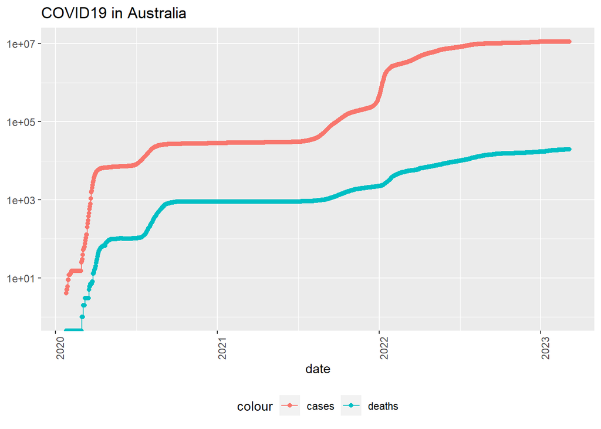

```r
country = "Australia"
global_by_country %>%
  filter(Country_Region == country) %>%
  filter(cases > 0 ) %>%
  ggplot(aes(x = date, y = cases)) +
  geom_line(aes(color = "cases")) +
  geom_point(aes(color = "cases")) +
  geom_line(aes(y = deaths, color="deaths")) +
  geom_point(aes(y = deaths, color="deaths")) +
  scale_y_log10() +
  theme(legend.position = "bottom",
        axis.text.x = element_text(angle=90)) +
  labs(title = str_c("COVID19 in ", country), y=NULL)
```

```r
global_totals <- global_by_country %>%
  group_by(Country_Region, date) %>%
  summarize(cases = sum(cases), deaths = sum(deaths),
            Population = sum(Population)) %>%
  mutate(deaths_per_mill = deaths *1000000 / Population) %>%
  select(Country_Region, date, cases, deaths, deaths_per_mill, Population) %>%
  ungroup()
global_totals
```

```
## # A tibble: 213,510 × 6
##    Country_Region date       cases deaths deaths_per_mill Population
##    <chr>          <date>     <dbl>  <dbl>           <dbl>      <dbl>
##  1 Afghanistan    2020-02-24     5      0               0   38928341
##  2 Afghanistan    2020-02-25     5      0               0   38928341
##  3 Afghanistan    2020-02-26     5      0               0   38928341
##  4 Afghanistan    2020-02-27     5      0               0   38928341
##  5 Afghanistan    2020-02-28     5      0               0   38928341
##  6 Afghanistan    2020-02-29     5      0               0   38928341
##  7 Afghanistan    2020-03-01     5      0               0   38928341
##  8 Afghanistan    2020-03-02     5      0               0   38928341
##  9 Afghanistan    2020-03-03     5      0               0   38928341
## 10 Afghanistan    2020-03-04     5      0               0   38928341
## # … with 213,500 more rows
```

```r
tail(global_totals)
```

```
## # A tibble: 6 × 6
##   Country_Region date        cases deaths deaths_per_mill Population
##   <chr>          <date>      <dbl>  <dbl>           <dbl>      <dbl>
## 1 Zimbabwe       2023-03-01 264127   5668            381.   14862927
## 2 Zimbabwe       2023-03-02 264127   5668            381.   14862927
## 3 Zimbabwe       2023-03-03 264127   5668            381.   14862927
## 4 Zimbabwe       2023-03-04 264127   5668            381.   14862927
## 5 Zimbabwe       2023-03-05 264127   5668            381.   14862927
## 6 Zimbabwe       2023-03-06 264127   5668            381.   14862927
```

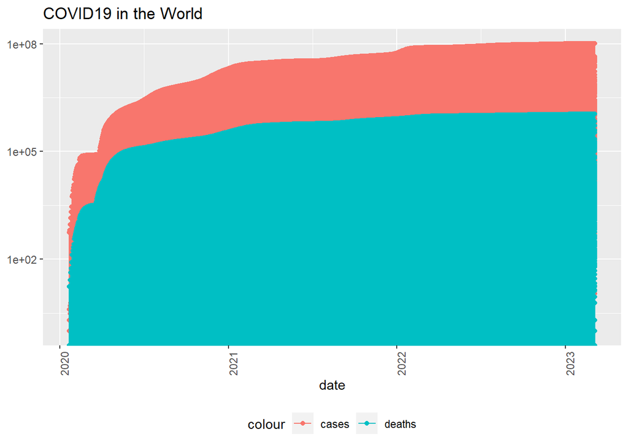

```r
# VISUALIZE
global_totals %>%
  filter(cases > 0) %>%
  ggplot(aes(x = date, y = cases)) +
  geom_line(aes(color = "cases")) +
  geom_point(aes(color = "cases")) +
  geom_line(aes(y = deaths, color = "deaths")) +
  geom_point(aes(y = deaths, color = "deaths")) +
  scale_y_log10() +
  theme(legend.position="bottom",
        axis.text.x = element_text(angle = 90)) +
  labs(title = "COVID19 in the World", y = NULL)
```

```r
max(global_totals$date)
```

```
## [1] "2023-03-06"
```

```r
max(global_totals$deaths)
```

```
## [1] 1122264
```

# ANALYZING

```r
global_by_country <- global_by_country %>%
  mutate(new_cases = cases - lag(cases),
         new_deaths = deaths - lag(deaths))
global_totals <- global_totals %>%
  mutate(new_cases = cases - lag(cases),
         new_deaths = deaths - lag(deaths))
tail(global_totals)
```

```
## # A tibble: 6 × 8
##   Country_Region date        cases deaths deaths_per_m…¹ Popul…² new_c…³ new_d…⁴
##   <chr>          <date>      <dbl>  <dbl>          <dbl>   <dbl>   <dbl>   <dbl>
## 1 Zimbabwe       2023-03-01 264127   5668           381.  1.49e7     206       5
## 2 Zimbabwe       2023-03-02 264127   5668           381.  1.49e7       0       0
## 3 Zimbabwe       2023-03-03 264127   5668           381.  1.49e7       0       0
## 4 Zimbabwe       2023-03-04 264127   5668           381.  1.49e7       0       0
## 5 Zimbabwe       2023-03-05 264127   5668           381.  1.49e7       0       0
## 6 Zimbabwe       2023-03-06 264127   5668           381.  1.49e7       0       0
## # … with abbreviated variable names ¹deaths_per_mill, ²Population, ³new_cases,
## #   ⁴new_deaths
```

```r
tail(global_totals %>% select(new_cases, new_deaths, everything()))
```

```
## # A tibble: 6 × 8
##   new_cases new_deaths Country_Region date        cases deaths deaths_…¹ Popul…²
##       <dbl>      <dbl> <chr>          <date>      <dbl>  <dbl>     <dbl>   <dbl>
## 1       206          5 Zimbabwe       2023-03-01 264127   5668      381.  1.49e7
## 2         0          0 Zimbabwe       2023-03-02 264127   5668      381.  1.49e7
## 3         0          0 Zimbabwe       2023-03-03 264127   5668      381.  1.49e7
## 4         0          0 Zimbabwe       2023-03-04 264127   5668      381.  1.49e7
## 5         0          0 Zimbabwe       2023-03-05 264127   5668      381.  1.49e7
## 6         0          0 Zimbabwe       2023-03-06 264127   5668      381.  1.49e7
## # … with abbreviated variable names ¹deaths_per_mill, ²Population
```

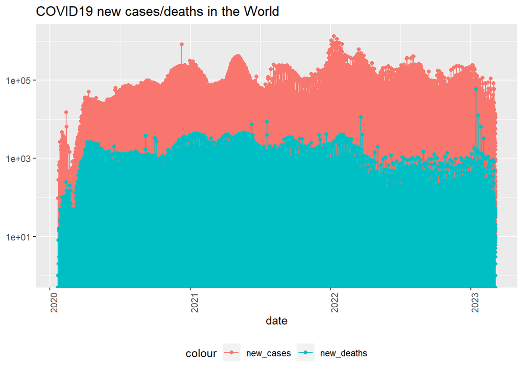

```r
global_totals %>%
  ggplot(aes(x = date, y = new_cases)) +
  geom_line(aes(color = "new_cases")) +
  geom_point(aes(color = "new_cases")) +
  geom_line(aes(y = new_deaths, color = "new_deaths")) +
  geom_point(aes(y = new_deaths, color = "new_deaths")) +
  scale_y_log10() +
  theme(legend.position="bottom",
        axis.text.x = element_text(angle = 90)) +
  labs(title = "COVID19 new cases/deaths in the World", y=NULL)
```

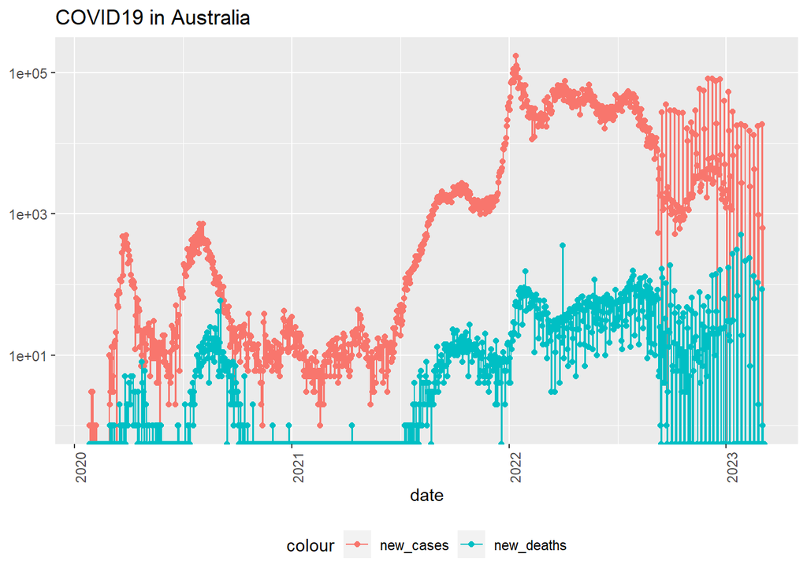

```r
global_by_country %>%
  filter(Country_Region == country) %>%
  filter(cases > 0 ) %>%
  ggplot(aes(x = date, y = new_cases)) +
  geom_line(aes(color = "new_cases")) +
  geom_point(aes(color = "new_cases")) +
  geom_line(aes(y = new_deaths, color="new_deaths")) +
  geom_point(aes(y = new_deaths, color="new_deaths")) +
  scale_y_log10() +
  theme(legend.position = "bottom",
        axis.text.x = element_text(angle=90)) +
  labs(title = str_c("COVID19 in ", country), y=NULL)
```

```r
# WHAT ARE THE WORST AND BEST COUNTRIES? SHOULD WE LOOK AT THE TOTAL CASES OR THE DEATH RATES PER 1000 PEOPLE?
global_country_totals <- global_by_country %>%
  group_by(Country_Region) %>%
  summarize(deaths = max(deaths), cases = max(cases),
            population = max(Population),
            cases_per_thou = 1000 * cases/population,
            deaths_per_thou = 1000 * deaths / population) %>%
  filter(cases > 0, population > 0)
global_country_totals %>%
  slice_min(deaths_per_thou, n = 10) #states has the smallest number of deaths_per_thousand
```

```
## # A tibble: 10 × 6
##    Country_Region deaths cases population cases_per_thou deaths_per_thou
##    <chr>           <dbl> <dbl>      <dbl>          <dbl>           <dbl>
##  1 Holy See            0    29        809     35.8              0
##  2 Tuvalu              0  2828      11792    240.               0
##  3 Korea, North        6     1   25778815      0.0000388        0.000233
##  4 Burundi            38 53631   11890781      4.51             0.00320
##  5 Chad              194  7678   16425859      0.467            0.0118
##  6 South Sudan       138 18368   11193729      1.64             0.0123
##  7 Niger             315  9508   24206636      0.393            0.0130
##  8 Tajikistan        125 17786    9537642      1.86             0.0131
##  9 Benin             163 27990   12123198      2.31             0.0134
## 10 Tanzania          846 42846   59734213      0.717            0.0142
```

```r
# 10 countries has the lowest COVID deaths
global_country_totals
```

```
## # A tibble: 194 × 6
##    Country_Region      deaths    cases population cases_per_thou deaths_per_thou
##    <chr>                <dbl>    <dbl>      <dbl>          <dbl>           <dbl>
##  1 Afghanistan           7896   209406   38928341           5.38          0.203
##  2 Albania               3598   334427    2877800         116.            1.25
##  3 Algeria               6881   271477   43851043           6.19          0.157
##  4 Andorra                165    47875      77265         620.            2.14
##  5 Angola                1933   105277   32866268           3.20          0.0588
##  6 Antigua and Barbuda    146     9106      97928          93.0           1.49
##  7 Argentina           130472 10044957   45195777         222.            2.89
##  8 Armenia               8721   446819    2963234         151.            2.94
##  9 Australia            19459 11385534   25459700         447.            0.764
## 10 Austria              21923  5943417    9006400         660.            2.43
## # … with 184 more rows
```

```r
global_country_totals %>%
  slice_max(deaths_per_thou, n = 10) %>%
  select(deaths_per_thou, cases_per_thou, everything())
```

```
## # A tibble: 10 × 6
##    deaths_per_thou cases_per_thou Country_Region         deaths   cases popula…¹
##              <dbl>          <dbl> <chr>                   <dbl>   <dbl>    <dbl>
##  1            6.66           136. Peru                   219513 4486934 32971846
##  2            5.50           187. Bulgaria                38219 1297243  6948445
##  3            5.05           227. Hungary                 48751 2195926  9660350
##  4            4.96           122. Bosnia and Herzegovina  16279  401636  3280815
##  5            4.64           166. North Macedonia          9662  346852  2083380
##  6            4.47           460. Montenegro               2807  288630   628062
##  7            4.38           309. Croatia                 17987 1269326  4105268
##  8            4.25           458. Georgia                 16965 1825598  3989175
##  9            3.97           431. Czechia                 42470 4614143 10708982
## 10            3.87           491. Slovakia                21031 2666427  5434712
## # … with abbreviated variable name ¹population
```

```r
# 10 countries has the highest COVID deaths
global_country_totals
```

```
## # A tibble: 194 × 6
##    Country_Region      deaths    cases population cases_per_thou deaths_per_thou
##    <chr>                <dbl>    <dbl>      <dbl>          <dbl>           <dbl>
##  1 Afghanistan           7896   209406   38928341           5.38          0.203
##  2 Albania               3598   334427    2877800         116.            1.25
##  3 Algeria               6881   271477   43851043           6.19          0.157
##  4 Andorra                165    47875      77265         620.            2.14
##  5 Angola                1933   105277   32866268           3.20          0.0588
##  6 Antigua and Barbuda    146     9106      97928          93.0           1.49
##  7 Argentina           130472 10044957   45195777         222.            2.89
##  8 Armenia               8721   446819    2963234         151.            2.94
##  9 Australia            19459 11385534   25459700         447.            0.764
## 10 Austria              21923  5943417    9006400         660.            2.43
## # … with 184 more rows
```